# Effects of Severe weather events on population health and economy

# Abstract

The basic goal of this report is to explore the NOAA Storm Database and answer some basic questions about severe weather events. we use the U.S. National Oceanic and Atmospheric Administration's (NOAA) storm database to answer the questions. for this purpose we use [this](https://d396qusza40orc.cloudfront.net/repdata%2Fdata%2FStormData.csv.bz2) specific databes. This database tracks characteristics of major storms and weather events in the United States, including when and where they occur, as well as estimates of any fatalities, injuries, and property damage.

we try to answer the following questions:

1. Across the United States, which types of events are most harmful with respect to population health?
2. Across the United States, which types of events have the greatest economic consequences?

# Data Processing

first of all we download, extract and load data into R:

```r
dat <- read.csv("StormData.csv.bz2", header = T, na.string = "")
dim(dat)  ## number of observations and variables
```

```
## [1] 902297     37
```

## Population health

to address the first question which is types of events are most harmful, we have to define the word harmful and what we mean by it in this report. we define most harmful events as events that have most number of fatalities and injuries. so we consider a number which is result of summing fatalities and injuries count for each event, to compare harmfulness of events.

in given dataset “FATALITIES” and “INJURIE” variables are used to show number of fatalites and injuries for each observation.

we also know “EVTYPE” variable indicates event types. according to table 2.1.1 of documentation we have only 48 events (the event names are listed in Appendix A). but inside the dataset, the number of events are quite a bit more than 48.

```r
length(unique(dat$EVTYPE))
```

```
## [1] 985
```

the reason for this considerable amount of difference is type errors and minor typing differences which are same in meaning but difference in name. for example events “Winter Weather” and “WINTER WEATHER” actually are pointing to same events. so after changing all event names to lower case:

```r
dat$EVTYPE <- tolower(dat$EVTYPE)
length(unique(dat$EVTYPE))
```

```
## [1] 898
```

we remove digits from events to avoid having different events like “hail 150” and “hail 100”.

```r
dat$EVTYPE <- gsub("\\d", "", dat$EVTYPE)
```

the result is still extremely high compared to actual number of events. another reason to the problem is none-word character (characters which are not a word character). for example “WINTER WEATHER MIX” and “WINTER WEATHER/MIX” are same events.

```r
dat$EVTYPE <- gsub("\\W", " ", dat$EVTYPE)  ## replace special chars with space
dat$EVTYPE <- gsub(" +", " ", dat$EVTYPE)  ## remove duplicate spaces
dat$EVTYPE <- gsub(" +$", "", dat$EVTYPE)  ## remove trailing space
dat$EVTYPE <- gsub("^ +", "", dat$EVTYPE)  ## remove trailing space
length(unique(dat$EVTYPE))
```

```
## [1] 714
```

some events like “summary of july” or “summary of sept” are not very informative and could be considered as “other” event.

```r
dat[grep("summary", dat$EVTYPE, ignore.case = T), 8] <- "other"
length(unique(dat$EVTYPE))
```

```
## [1] 695
```

there are some other anomalies like “hvy hail” and “deep hail”. we want to coarsely change all of them to “hail”, which is reasonable (we have to be careful to not confuse “hail” with “marin hail” which are considered different events in documentation), but requires some more codes (actually i did implement it with stringdist R package but results were too coarse, see Appendix B). we stop here and let it be it is. the dataset which we use to answer our first question is `q1` data frame.

```r
both <- dat$FATALITIES + dat$INJURIE
q1 <- data.frame(event = dat$EVTYPE, fatalities = dat$FATALITIES, injuries = dat$INJURIE,
    both = both)
head(q1)
```

```
##     event fatalities injuries both
## 1 tornado          0       15   15
## 2 tornado          0        0    0
## 3 tornado          0        2    2
## 4 tornado          0        2    2
## 5 tornado          0        2    2
## 6 tornado          0        6    6
```

## Economic consequences

we know “PROPDMG” and “CROPDMG” are variables that indicate economic consequences of each observed event. there are also “PROPDMGEXP” and “CROPDMGEXP” which need to be merged inorder to have a meaningful cost in appropriate currency unit.

```r
levels(dat$PROPDMGEXP)
```

```
##  [1] "-" "?" "+" "0" "1" "2" "3" "4" "5" "6" "7" "8" "B" "h" "H" "K" "m"
## [18] "M"
```

```r
dat$PROPDMGEXP <- gsub("^1$", "10", dat$PROPDMGEXP)
dat$PROPDMGEXP <- gsub("^[0\\-\\+\\?]", "1", dat$PROPDMGEXP)
dat$PROPDMGEXP <- gsub("\\-", "1", dat$PROPDMGEXP)
dat$PROPDMGEXP <- gsub("2", "100", dat$PROPDMGEXP)
dat$PROPDMGEXP <- gsub("[hHkK3]", "1000", dat$PROPDMGEXP)
dat$PROPDMGEXP <- gsub("4", "10000", dat$PROPDMGEXP)
dat$PROPDMGEXP <- gsub("5", "100000", dat$PROPDMGEXP)
dat$PROPDMGEXP <- gsub("[mM6]", "1000000", dat$PROPDMGEXP)
dat$PROPDMGEXP <- gsub("7", "1000000", dat$PROPDMGEXP)
dat$PROPDMGEXP <- gsub("8", "10000000", dat$PROPDMGEXP)
dat$PROPDMGEXP <- gsub("[bB9]", "1000000000", dat$PROPDMGEXP)
dat[which(is.na(dat$PROPDMGEXP)), 26] <- 1
levels(dat$CROPDMGEXP)
```

```
## [1] "?" "0" "2" "B" "k" "K" "m" "M"
```

```r
dat$CROPDMGEXP <- gsub("2", "100", dat$CROPDMGEXP)
dat$CROPDMGEXP <- gsub("[hHkK3]", "1000", dat$CROPDMGEXP)
dat$CROPDMGEXP <- gsub("[mM6]", "1000000", dat$CROPDMGEXP)
dat$CROPDMGEXP <- gsub("[bB9]", "1000000000", dat$CROPDMGEXP)
dat$CROPDMGEXP <- gsub("^[0\\-\\+\\?]", "1", dat$CROPDMGEXP)
dat[which(is.na(dat$CROPDMGEXP)), 28] <- 1
```

the dataset used to answer our second question is `q2` data frame.

```r
propDMG <- dat$PROPDMG * as.numeric(dat$PROPDMGEXP)
cropDMG <- dat$CROPDMG * as.numeric(dat$CROPDMGEXP)
both <- cropDMG + propDMG
q2 <- data.frame(event = dat$EVTYPE, propDmg = propDMG, cropDmg = cropDMG, both = both)
head(q2)
```

```
##     event propDmg cropDmg  both
## 1 tornado   25000       0 25000
## 2 tornado    2500       0  2500
## 3 tornado   25000       0 25000
## 4 tornado    2500       0  2500
## 5 tornado    2500       0  2500
## 6 tornado    2500       0  2500
```

# Results

as mentioned before, we are trying to answer two question about weather events. in last section we load and prepared our dataset for data analysis. now we have two datasets to work with. first dataset (“q1”) contains human related variables for each observation and second dataset (“q2”) contains economy related variables for each weather event. in following subsections we explore and examin more thoroughly each questions

## Human health related costs

in this subsection we want to answer following question: “which types of events are most harmful with respect to population health?”.

we've already talked about how overall costs for first dataset is calculated. here we want to find top ten most costly events in our dataset:

```r
x1 <- aggregate(q1[, 2:4], list(event = q1$event), sum)
as.character(x1[which.max(x1$both), 1])  ## the most severe event
```

```
## [1] "tornado"
```

```r
as.character(head(x1[order(x1$both, decreasing = T), 1]))
```

```
## [1] "tornado"        "excessive heat" "tstm wind"      "flood"
## [5] "lightning"      "heat"
```

```r
top101 <- x1[order(x1$both, decreasing = T), ][1:10, ]
```

ggplot system is used for plotting

```r
library(ggplot2)
```

in following plot the top 10 most costly events are showed in x axis and their relative overall cost in y axis. the costs are also seperated by injuries and fatalities. it is possible to weight the cost data for example weight injuries to be less important than fatalities of each event, but treat both injuries and fatalities as they are at same importance.

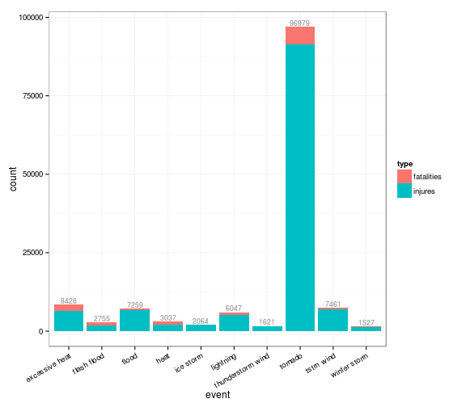

```r
p1 <- data.frame(event = top101[, 1], count = top101[, 2], type = "fatalities")
p1 <- rbind(p1, data.frame(event = top101[, 1], count = top101[, 3], type = "injures"))
p1 <- cbind(p1, both = c(top101$both, top101$both))
ggplot(p1, aes(x = event, y = count, fill = type, order = order(type, decreasing = T))) +
    geom_bar(stat = "identity") + theme_bw() + geom_text(aes(label = both, y = both),
    vjust = -0.2, size = 3, color = "darkgrey") + theme(axis.text.x = element_text(angle = 30,
    hjust = 1))
```

## Economy related costs

here we want to answer our second question which is: “which types of events have the greatest economic consequences?”

we follow the same steps in previous section, we find top 10 most costly events and plot them.

```r
x2 <- aggregate(q2[, 2:4], list(event = q2$event), sum)
as.character(x2[which.max(x2$both), 1])  ## the most severe event
```

```
## [1] "flood"
```

```r
as.character(head(x2[order(x2$both, decreasing = T), 1]))
```

```
## [1] "flood"             "hurricane typhoon" "tornado"
## [4] "storm surge"       "hail"              "flash flood"
```

```r
top102 <- x2[order(x2$both, decreasing = T), ][1:10, ]
```

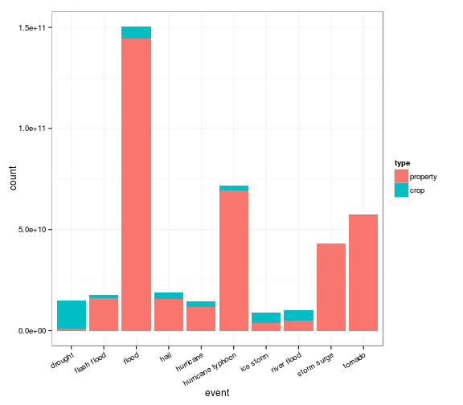

```r
p2 <- data.frame(event = top102[, 1], count = top102[, 2], type = "property")
p2 <- rbind(p2, data.frame(event = top102[, 1], count = top102[, 3], type = "crop"))
p2 <- cbind(p2, both = c(top102$both, top102$both))
ggplot(p2, aes(x = event, y = count, fill = type)) + geom_bar(stat = "identity") +
    theme_bw() + theme(axis.text.x = element_text(angle = 30, hjust = 1))
```

## Relation between human and economy related events

here we compare top ten most severe events of both types to see if they are related or not. as first attempt we can see that only 40% of top ten severe events are same in both categories.

```r
events <- sort(unique(c(as.character(top101$event), as.character(top102$event))))
((nrow(top101) + nrow(top102)) - length(events))/nrow(top101) * 100
```

```
## [1] 40
```

we now normalize the two data by dividing by their most extreme value inorder to compare them. following plot shows that in fact the most severe event regarding human health is not the most severe weather event in the economical point of view.

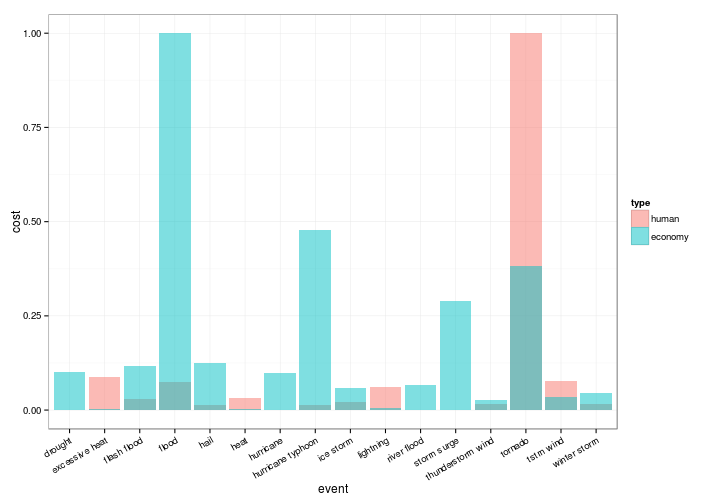

```r
c1 <- x1[which(x1$event %in% events), 4]
c2 <- x2[which(x2$event %in% events), 4]
p3 <- data.frame(event = events, cost = c1/max(c1), type = "human")
p3 <- rbind(p3, data.frame(event = events, cost = c2/max(c2), type = "economy"))
ggplot(p3, aes(x = event, y = cost, fill = type)) + theme_bw() + geom_histogram(stat = "identity",
    position = "identity", alpha = 0.5) + theme(axis.text.x = element_text(angle = 30,
    hjust = 1))
```

# Summary

with our assumptions and approximations we found out that most severe weather event with respect to human health is tornado and most severe weather event with respect to economy is flood.

inorder to improve the result, we can define a new variable, significance of an event by dividing cost by frequency of occurrence. this new variable shows how costly is each occurrence of each event. it is possible to calulate significance of events to decide better about severance of each events we can also track the process of worst events to help us to see posible patterns of events in time.

# Appendix A

events according to table 2.1.1:

```
  Astronomical Low Tide, Avalanche, Blizzard, Coastal Flood, Cold/Wind Chill, Debris Flow, Dense Fog, Dense Smoke, Drought, Dust Devil, Dust Storm, Excessive Heat, Extreme Cold/Wind Chill, Flash Flood, Flood, Frost/Freeze, Funnel Cloud, Freezing Fog, Hail, Heat, Heavy Rain, Heavy Snow, High Surf, High Wind, Hurricane (Typhoon), Ice Storm, Lake-Effect Snow, Lakeshore Flood, Lightning, Marine Hail, Marine High Wind, Marine Strong Wind, Marine Thunderstorm Wind, Rip Current, Seiche, Sleet, Storm Surge/Tide, Strong Wind, Thunderstorm Wind, Tornado, Tropical Depression, Tropical Storm, Tsunami, Volcanic Ash, Waterspout, Wildfire, Winter Storm, Winter Weather
```

# Appendix B

use only 48 events from documentation:

```
  library(stringdist)
  events <- readLines("events.txt")  ## events.txt contains 48 events
  events <- tolower(events)
  events <- c(events, "other")  ## we use other for unkown events
  x <- lapply(dat$EVTYPE, function(x) events[which.min(stringdist(x, events ,method="lcs"))])
  dat$EVTYPE <- as.character(x)
```